# ###Revisiting COVID-19 Data in Europe: Incidence, Mortality and Vaccination###

Ololade Gbadebo

### Results

To determine the regional difference in the epidemiology and vaccination rates, I compared the incidence, mortality and vaccination rates between the regions in Europe. Necessary columns (location, new case, new vaccinations and population) were filtered from the full data. Missing data were affecting the analysis. Because 3 variables were involved, a straightforward deletion was not feasible. Those missing data were replaced with zero. The raw dataset has the data for United Kingdom and the constituent countries. To avoid replicating data, the constituent countries were removed. A table of European regions and countries was manually made and joined to the data table using location/country as the unique identifier. Cases, deaths and vaccinations were summed up per region and theory values per 100 people were calculated. The regional COVID-19 epidemiology and vaccination rates between January 1, 2020 and April 31, 2024 are provided (Table 1). Incidence was highest in Western Europe with 51.26 cases per hundred people, while British Isles had the highest mortality (0.33 deaths per hundred) and vaccination (218.23 vaccinations per hundred people) rates.

Table 1. COVID-19 epidemiology and vaccination rates in European regions until April 31, 2024.

| Region | Total cases per hundred | Total deaths per hundred | Total vaccinations per hundred |
| --- | --- | --- | --- |
| British Isles | 36.81 | 0.33 | 218.23 |
| Eastern Europe | 17.84 | 0.30 | 95.23 |
| Northern Europe | 36.71 | 0.22 | 69.29 |
| Southern Europe | 39.19 | 0.31 | 161.09 |
| Western Europe | 51.26 | 0.22 | 199.31 |

Aside the region, a difference in prevalence across countries may also be expected. To confirm this, the data was then analyzed to determine the number of cases per capita between January 1, 2020 and December 31, 2023. The data was capped that that time because upon manual overview of the data, some countries were without data after December 2023. The cumulative number of cases per per country was determined and divided by their respective populations. Cyprus had the highest prevalence, followed closely by San Marino (Figure 1). Belarus and Vatican have a least incidence which may be due to different factors including low reporting rate and limited surveillance.

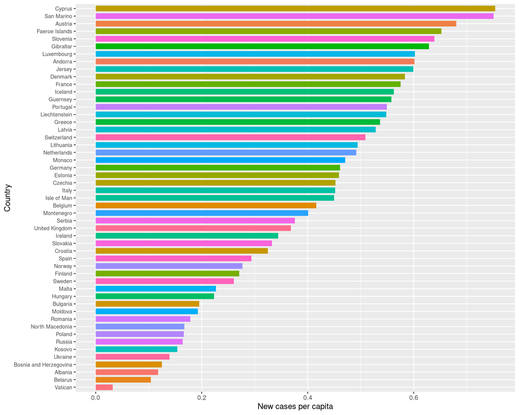

Figure 1. COVID-19 cases per capita in European countries. Data was sourced from Our World In Data and the coverage in this plot was January 2020 - December 2023. Cyprus had the highest prevalence, followed closely by San Marino while it was least in Vatican.

Moreover, the vaccination rates of the European countries were looked at. It is important to understand the trend of vaccination over the past years, perhaps there were moments of high vaccination rates and time there were plateaus in the curves. To avoid congestion in the plot, 12 countries were selected based on their high data reporting. Also, the analysis was stopped at December 2023 for uniformity. Generally, a sharp increase in cumulative vaccinations per 100 people was noticed between the from the second quarter of 2021 up till the first quarter of 2022 (Figure 2). This was expected since that was the period COVID-19 vaccines were approved and rolled out globally. Statistical analysis shows a significant difference (ANOVA p-value: 0.0000, R-squared:0.8467”) in the vaccination trend in the selected country between January 2020 and December 2023. This suggests that different factors peculiar to each selected country as well as time of the year influences COVID-19 vaccination rates.

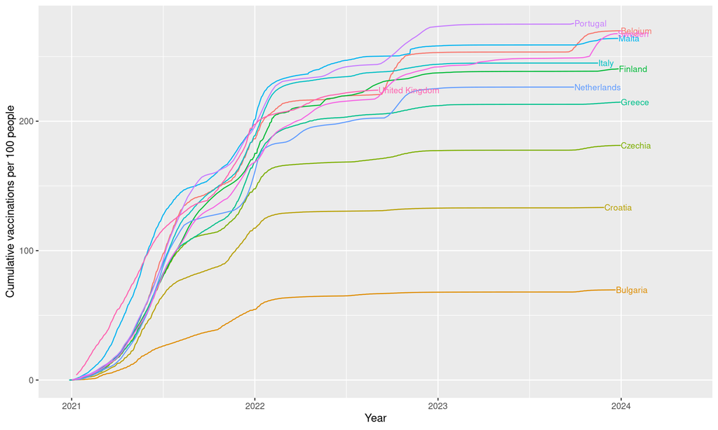

Furthermore, I analyzed the data to see the trend of monthly vaccination in selected countries. These countries were selected because they reported adequate vaccination data necessary for this analysis. The end period for this analysis was December 2023. The daily vaccination data for each selected country was summed up per month. The plot shows that vaccination began in Belgium, Czechia and Italy in January 2021 followed briefly later by other countries. There was a sharp increase in the vaccination rate through the first half of 2021 followed by a decline that lasted about 4 months. This decline was again followed by an increased vaccination rates and an eventual decline and flattening in the first quarter of 2022. However, Belgium recorded a spike in vaccination between August and November 2022 (Figure 3).

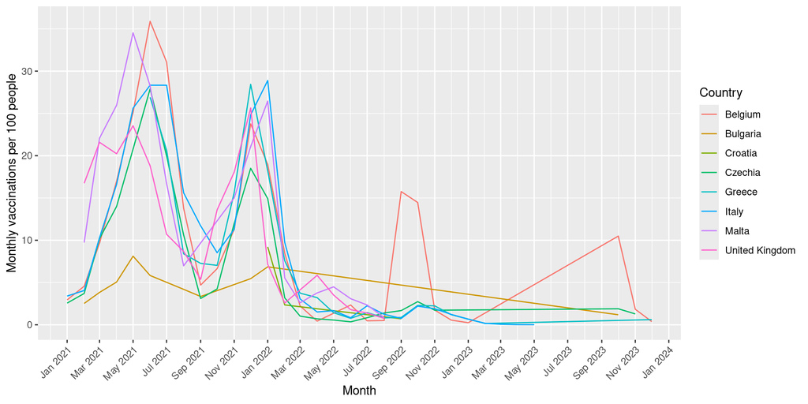

Figure 3. Monthly vaccination trend in selected European countries. Data was sourced from Our World In Data and the coverage in this plot was January 2020 - December 2023. Vaccination began in Belgium, Czechia and Italy in January 2021 followed briefly later by other countries. Generally, there was an initial increase in vaccination rates, followed by a decline that lasted 4 months, then an increase and subsequent decline and flattening. Statistical analysis shows a significant difference in the monthly vaccinations per 100 people trend across the different selected countries (ANOVA p-value: 4.284272e-10 R-squared: 0.3519848 ).

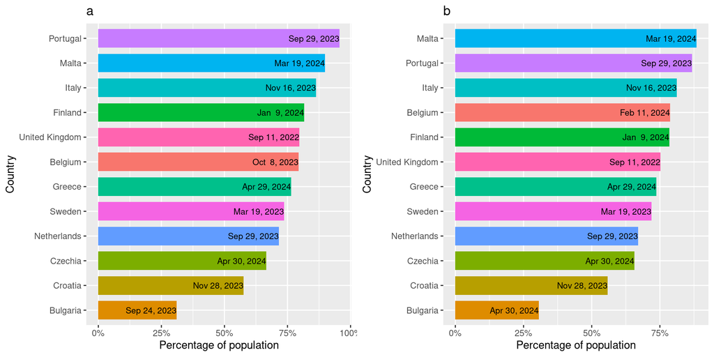

Figure 4. Percentages of the populations of selected countries that have received at least one dose of the COVID-19 vaccine (a) or have been fully vaccinated against COVID-19 (b). Data was sourced from Our World In Data and the coverage in this plot was January 2020 - April 2024. Date on each shows the end date for the vaccination reportage for each country.

One of the major risk factors for respiratory infection is season. During cold season, susceptible between are likely to come down with allegy, cold and flu. Then I analyzed the data to answer the question of the impact of season on the incidence and mortality rates of COVID-19. Since the winter season cuts across two, the season year was given the year it is starting. e.g. December 2021, January 2022 and February 2022 are classified as Winter 2022. Data was visualized with Box plots containing multiple samples (years) per season were created (Figure 5). I conducted a linear regression analysis to explore the influence of seasonality on the number of COVID-19 cases and deaths. The analysis showed that the influence of season on the number of COVID-19 cases is not statistically significant (ANOVA p-value:0.8870). Conversely, there is a statistically relevant influence of season on the number of COVID-19 deaths (ANOVA p-value: 0.0042). This suggests that seasonal variations do not significantly impact the case count while they appear to play a role in mortality rates.

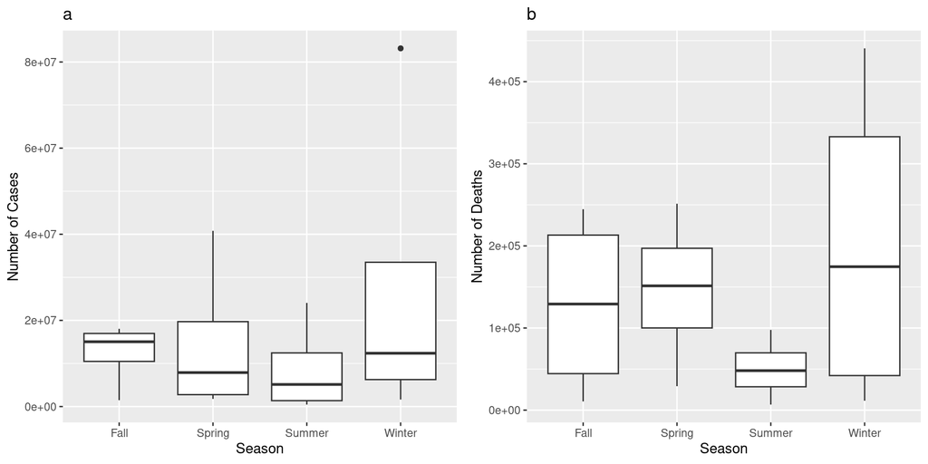

Figure 5. Seasonal changes in the number of cases (a) and deaths (b) caused by COVID-19 between March 2020 and February 2024. Data was downloaded from Our World in Data website and analyzed. Influence of season on the number of cases is not statistically significant (ANOVA p-value: 0.8870719 R-squared: -0.4026093 ). However, a statistically relevant influence of season on number of deaths was observed (ANOVA p-value: 0.004184515 R-squared: 0.7688419 ).

In this report, I have considered the incidence, mortality and vaccination rates of COVID-19. Data was analyzed using shell script, and visualized using the ggplot2 package in R. Incidence, mortality and vaccination rates varies across the regions of the continent. Moreover, there were significant influence of date and country factors on vaccination rates. Seasonal changes had no significant influence on the number of new cases while they significantly impact mortality rates.